# Readmission rates fo Type 2 Diabetics

Kenan Sooklall

CUNY-SPS  
ksooklall100@gmail.com

2022-05-03

Abstract

### Introduction

Type 2 diabetes has reached epidemic proportions worldwide. According to the WHO diabetes has entered the top 10 causes of death, following a significant percentage increase of 70% since 2000. Diabetes is also responsible for the largest rise in male deaths among the top 10, with an 80% increase since 2000. Diabetes is a group of diseases that affect insulin production and use. In type 1 diabetes, the pancreas can’t produce insulin. The cause isn’t known. In type 2 diabetes, the pancreas doesn’t produce enough insulin, or insulin can’t be used effectively. Type 2 diabetes can be caused by a number of factors, including poor diet, lack of exercise, and being overweight.

Throughout this paper diabetes is a shorthand for type 2 diabetes. According to the source the dataset represents 10 years (1999-2008) of clinical care at 130 US hospitals and integrated delivery networks. It includes over 50 features representing patient and hospital outcomes. The data contained information that satisfied the following criteria. It is an inpatient encounter (a hospital admission). It is a diabetic encounter, that is, one during which any kind of diabetes was entered to the system as a diagnosis. The length of stay was at least 1 day and at most 14 days. Laboratory tests were performed during the encounter. Medications were administered during the encounter.

The data contains such attributes as patient number, race, gender, age, admission type, time in hospital, medical specialty of admitting physician, number of lab test performed, HbA1c test result, diagnosis, number of medication, diabetic medications, number of outpatient, inpatient, and emergency visits in the year before the hospitalization, etc.

### Preprocessing

The data set was obtained from UC Irvine and contains 101766 rows and 50 columns. The patient column contains 71518 unique patients with 28784 readmitted and 28781 not readmitted. To avoid over fitting on a single patient all duplicated patient data was dropped. Then downsampling was conducted for the minority class leaving the data set with 57568 rows. The 50 columns can be broken down in to 5 parts, admission data, lab diagnosis, patient details, diagnosis data and diabetic drugs, Table 1.

The data set has “?” to signify a missing value, so “?” were replaced with NaNs for all columns. The weight, payer code and medical specialty were dropped for having too many NaNs. Drug columns examide, citoglipton and glimepiride-pioglitazone were dropped because they only had 1 unique value. Encounter ID was dropped as it doesn’t provide any informative information. Race was dropped as it might make the model not useful and can lead to uninformative result.

The target column readmitted was transformed with NO as 0 and all other values as 1. This remapping transforms readmitted from 3 unique values to 2, changing this analysis to binary classification. The age column was bucketed into young (age<30), adult (30<age<60) and old (age>60) then one hot encoded.

The diagnosis columns diag_1,2 and 3 were mapped according to the icd9 codes, then one hot encoded. The drug columns were mapped NO as 0 and all other values as 1. The only NaN rows were diagnosis, so they were all dropped as imputation is not possible.

Admission type ID, Discharge disposition ID and Admission source ID were mapping according to the source paper with a few major changes. Discharge disposition ID was reduced to “other” , “home” and NaN. Admission source ID was reduced to “emergency”, “referral”, “other” and NaN. Admission type ID was not changed from the source except replacing NULL and not available with NaN.

Columns to great interest are glucose serum test result and A1c test result. Glucose serum test is a numeric value that measures blood sugar level, a value of 126 mg/dL or higher indicates the patient is diabetic. The A1C test measures the percentage of your red blood cells that have sugar-coated hemoglobin, a value of 6.5% or above indicates the patient is diabetic.

| Feature.Name | Type | Description.and.Values | missing |
| --- | --- | --- | --- |
| Encounter ID | Numeric | Unique identifier of an encounter | 0.0 |
| Patient number | Numeric | Unique identifier of a patient | 0.0 |
| Race | Nominal | Caucasian, Asian, African American, Hispanic, and other | 2.2 |
| Gender Values | Nominal | male, female, and unknown/invalid | 0.0 |
| Age | Nominal | Grouped in 10-year intervals 0, 10), 10, 20), …, 90, 100) | 0.0 |
| Weight | Numeric | Weight in pounds | 96.9 |
| Admission type | Nominal | Integer identifier corresponding to 9 distinct values, for example, emergency, urgent, elective, newborn, and not available | 0.0 |
| Discharge disposition | Nominal | Integer identifier corresponding to 29 distinct values, for example, discharged to home, expired, and not available | 0.0 |
| Admission source | Nominal | Integer identifier corresponding to 21 distinct values, for example, physician referral, emergency room, and transfer from a hospital | 0.0 |
| Time in hospital | Numeric | Integer number of days between admission and discharge | 0.0 |
| Payer code | Nominal | Integer identifier corresponding to 23 distinct values, for example, Blue Cross/Blue Shield, Medicare, and self-pay Medical | 39.6 |
| Medical specialty | Nominal | Integer identifier of a specialty of the admitting physician, corresponding to 84 distinct values, for example, cardiology, internal medicine, family/general practice, and surgeon | 49.1 |
| Number of lab procedures | Numeric | Number of lab tests performed during the encounter | 0.0 |
| Number of procedures | Numeric | Number of procedures (other than lab tests) performed during the encounter | 0.0 |
| Number of medications | Numeric | Number of distinct generic names administered during the encounter | 0.0 |
| Number of outpatient visits | Numeric | Number of outpatient visits of the patient in the year preceding the encounter | 0.0 |
| Number of emergency visits | Numeric | Number of emergency visits of the patient in the year preceding the encounter | 0.0 |
| Number of inpatient visits | Numeric | Number of inpatient visits of the patient in the year preceding the encounter | 0.0 |
| Diagnosis 1 | Nominal | The primary diagnosis (coded as first three digits of ICD9); 848 distinct values | 0.0 |
| Diagnosis 2 | Nominal | Secondary diagnosis (coded as first three digits of ICD9); 923 distinct values | 0.4 |
| Diagnosis 3 | Nominal | Additional secondary diagnosis (coded as first three digits of ICD9); 954 distinct values | 1.4 |
| Number of diagnoses | Numeric | Number of diagnoses entered to the system 0% | 0.0 |
| Glucose serum test | Nominal | result Indicates the range of the result or if the test was not taken. Values ‘>200’, ‘>300’, ‘normal’ and ‘none’ if not measured | 0.0 |
| A1c test result | Nominal | Indicates the range of the result or if the test was not taken. Values ‘>8’ if the result was greater than 8%, ‘>7’ if the result was greater than 7% but less than 8%, ‘normal’ if the result was less … | 0.0 |
| Change of medications | Nominal | Indicates if there was a change in diabetic medications (either dosage or generic name). Values ‘change’ and ‘no change’ | 0.0 |
| Diabetes medications | Nominal | Indicates if there was any diabetic medication prescribed. Values ‘yes’ and ‘no’ | 0.0 |
| 24 features for medications | Nominal | glyburide-metformin, glipizide-metformin, glimepiride-pioglitazone, metformin-rosiglitazone, and metformin-pioglitazone, the feature indicates whether the drug was prescribed or there was a change in … | 0.0 |
| Readmitted Days | Nominal | Values ‘<30’ if the patient was readmitted in less than 30 days, ‘>30’ if the patient was readmitted in more than 30 days, and ‘No’ for no record of readmission | 0.0 |

### Exploratory Data Analysis

There is a weak relationship with drugs taken and a patient being readmitted. The only drug with a high readmission is insulin which is expected since insulin plays a major role in a patient becoming diabetic. Figure 1 shows that most of the readmitting comes from older individuals. The older population is represented the most and the younger population the least. Figure 2 shows that A1C results greater than 8% have a big affect on readmission; however, for patients who didn’t get readmitted there are a lot of adults with A1C results of greater than 8%. Figure 3 shows a big spike for normal glucose levels for both classes. There is also very similar levels of all age groups between both classes. For both A1C results and max glucose serum the younger portion of the population contributed the least to readmission.

Figure 4 shows how time in hospital is right skewed with no distinction between classes. Figure 5 and 6 shows the number of lab procedures and number of medications are normally distributed with the former having a spike at the start and the ladder being slightly right skewed.

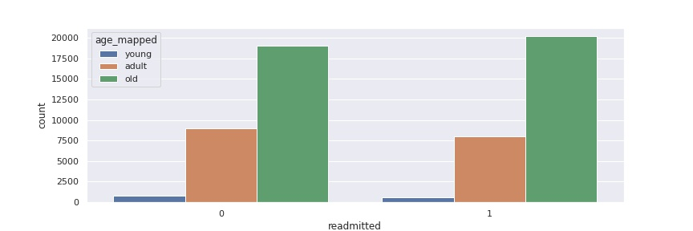

Age vs Readmission

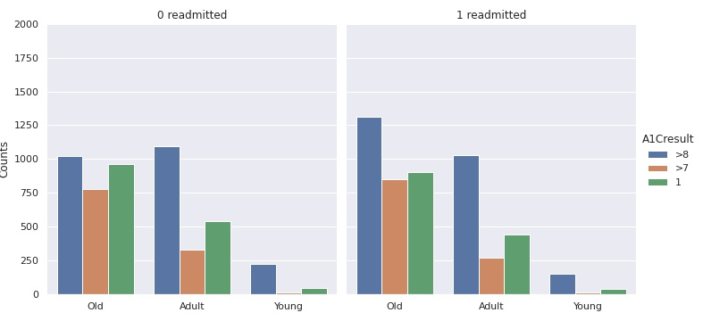

A1Cresults vs readmission

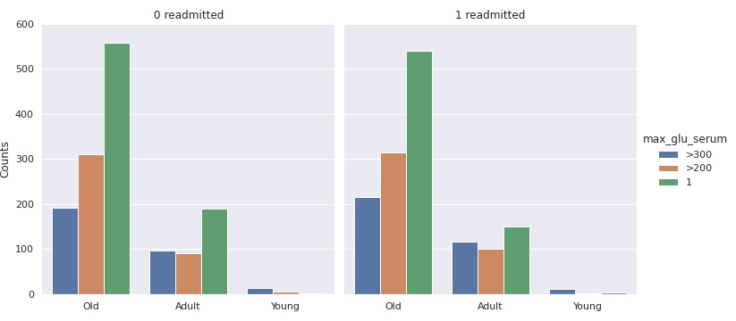

Max Glucose Serum vs readmission

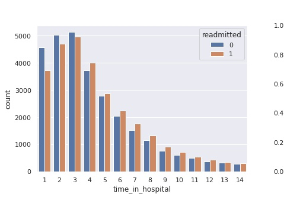

Time in hospital

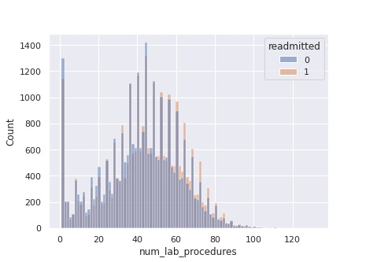

Number of lab procedures

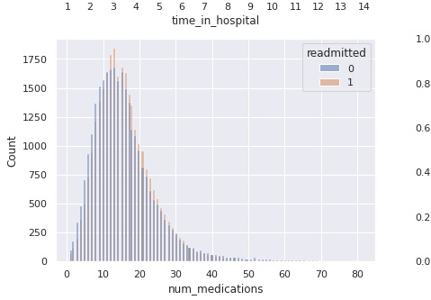

Number of medications

### Modeling

Three models SVM, Logistic Regression and Random Forest Classifier were trained with cross validation using different combinations of features. Model hyper parameters were tuned with grid search. The dataset was split into training and testing with the test set containing 15% of the data. The best models were fitted to the training set with the best parameters and then feature importances are plotted. Numeric columns were standardized by subtracting the mean and dividing by the standard deviation thus having a mean of 0 and std of 1. All other columns were fed into the model without further processing unless specified.

The first dataset used all features, lab data, drug data and patient data. This model includes gender, old, young, adult, time in hospital, num lab procedures, num procedures, num medications, number diagnoses, diabetesMed, change, max glu serum num, and A1Cresult num. Max glu serum num, and A1Cresult num were engineered to become binary with 0 as normal and all other values as 1.

The last round of modeling is done with glucose serum test result and A1C test result as those are the features that a patient can control through diet or exercise. Age was also added to this dataset to see if it plays a bigger role. The dataset was filter for rows that only contain values for both features leaving 208 rows. Both glucose serum test and A1c test results were one hot encoded.

### Results and Dicussion

Model 1 Classification Report

| target | precision | recall | f1.score | support |
| --- | --- | --- | --- | --- |
| no | 0.59 | 0.48 | 0.53 | 4377 |
| yes | 0.55 | 0.66 | 0.60 | 4258 |

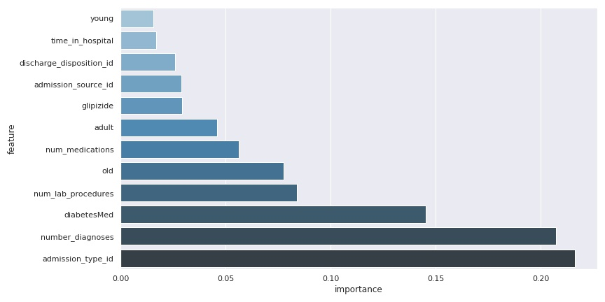

Model 1 Feature Importance

Model 2 Classification Report

| target | precision | recall | f1.score | support |
| --- | --- | --- | --- | --- |
| no | 0.55 | 0.47 | 0.51 | 763 |
| yes | 0.53 | 0.61 | 0.57 | 745 |

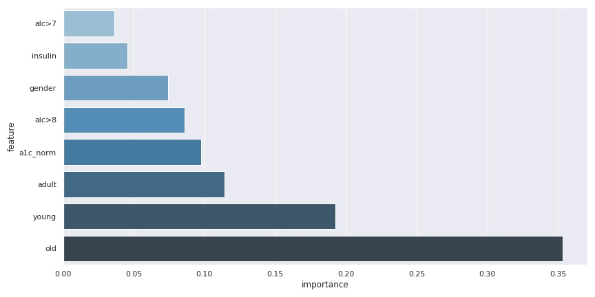

Model 2 Feature Importance

Model 3 Classification Report

| target | precision | recall | f1.score | support |
| --- | --- | --- | --- | --- |
| no | 0.00 | 0 | 0.00 | 11 |
| yes | 0.65 | 1 | 0.78 | 20 |

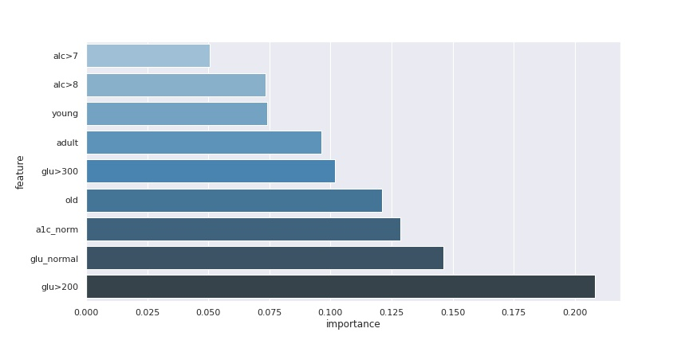

Model 3 Feature Importance

Model 4 Classification Report

| target | precision | recall | f1.score | support |
| --- | --- | --- | --- | --- |
| no | 0.53 | 0.59 | 0.56 | 4335 |
| yes | 0.53 | 0.47 | 0.50 | 4300 |

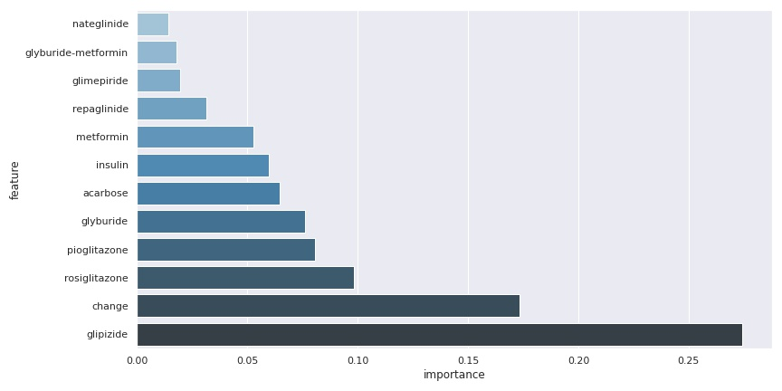

Model 4 Feature Importance

### Source & Citation

The data are submitted on behalf of the Center for Clinical and Translational Research, Virginia Commonwealth University, a recipient of NIH CTSA grant UL1 TR00058 and a recipient of the CERNER data. John Clore (jclore ‘@’ vcu.edu), Krzysztof J. Cios (kcios ‘@’ vcu.edu), Jon DeShazo (jpdeshazo ‘@’ vcu.edu), and Beata Strack (strackb ‘@’ vcu.edu). This data is a de-identified abstract of the Health Facts database (Cerner Corporation, Kansas City, MO).

https://archive-beta.ics.uci.edu/ml/datasets/diabetes+130+us+hospitals+for+years+1999+2008

Beata Strack, Jonathan P. DeShazo, Chris Gennings, Juan L. Olmo, Sebastian Ventura, Krzysztof J. Cios, and John N. Clore, “Impact of HbA1c Measurement on Hospital Readmission Rates: Analysis of 70,000 Clinical Database Patient Records,” BioMed Research International, vol. 2014, Article ID 781670, 11 pages, 2014.

### References

https://www.cdc.gov/diabetes/basics/getting-tested.html#:~:text=This%20measures%20your%20blood%20sugar,higher%20indicates%20you%20have%20diabetes.

https://www.mayoclinic.org/diseases-conditions/type-2-diabetes/symptoms-causes/syc-20351193